# Operating model for Haddock (*Melanogrammus aeglefinus*)

A case-study based on the Faroe Islands stock to investigate increase in catchability

A. Hordyk (a.hordyk@oceans.ubc.ca)

May 2018

# Introduction

The operating model is based on the Faroe Island haddock fishery in 1996. After 1996 the fishery switched to effort controls. Eigaard et al (2011) report an average annual increase in catchability of 9% after 1996.

The base-case OM assumes that future catchability is variable but stable.

The first alternative OM assumes half of the reported annual increase in catchability - 4.5%.

The second alternative OM assumes the the reported annual increase in catchability - 9%.

# Operating Model

The OM rdata file can be downloaded from here

Download and import into R using `myOM <- readRDS('OM.rdata')`

## Species Information

**Species**: *Melanogrammus aeglefinus*

**Common Name**: *Haddock*

**Management Agency**:

**Region**: Faroe Islands

## OM Parameters

**OM Name**: Name of the operating model: Haddock_Faroe_Islands

**proyears**: The number of projected years: 50

**interval**: The assessment interval - how often would you like to update the management system? 4

**pstar**: The percentile of the sample of the management recommendation for each method: 0.5

**maxF**: Maximum instantaneous fishing mortality rate that may be simulated for any given age class: 0.8

**reps**: Number of samples of the management recommendation for each method. Note that when this is set to 1, the mean value of the data inputs is used. 1

**Source**: A reference to a website or article from which parameters were taken to define the operating model

# Stock Parameters

### Mortality and age: maxage, R0, M, Msd

**maxage**: The maximum age of individuals that is simulated (there is no plus group ). Single value. Positive integer

Specified Value(s): 25

Maximum age was set a little higher than the maximum observed age of 20 years.

**R0**: The magnitude of unfished recruitment. Single value. Positive real number

Specified Value(s): 1000

Scaling parameter set at arbitrary value.

**M**: Natural mortality rate. Uniform distribution lower and upper bounds. Positive real number

Specified Value(s): 0.2, 0.2

Natural mortality was fixed at the rate used in the ICES 2013 assessement.

**Msd**: Inter-annual variability in natural mortality rate expressed as a coefficient of variation. Uniform distribution lower and upper bounds. Non-negative real numbers

Specified Value(s): 0.05, 0.1

Given that *M* is poorly quantified in most fishery settings, the annual variability in *M* is poorly known but likely to vary due to variability in predation pressure, food availability, disease and the density of the stock and related stocks that compete for prey or cannibalize recruits. To address the possibility of *M* changing among years in these simulations we set a modest, arbitrary level of inter-annual variability with a lognormal CV of between 5% and 10% (i.e. 0.05 - 0.1), corresponding with 95% probability interval of +/-10% to +/- 20%.

### Natural Mortality Parameters

#### Sampled Parameters

Histograms of simulations of `M`, and `Msd` parameters, with vertical colored lines indicating 3 randomly drawn values used in other plots:

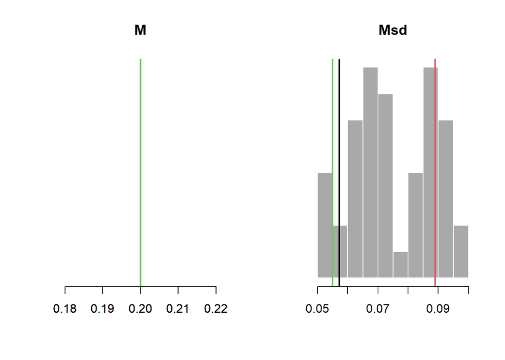

#### Time-Series

The average natural mortality rate by year for adult fish for 3 simulations. The vertical dashed line indicates the end of the historical period:

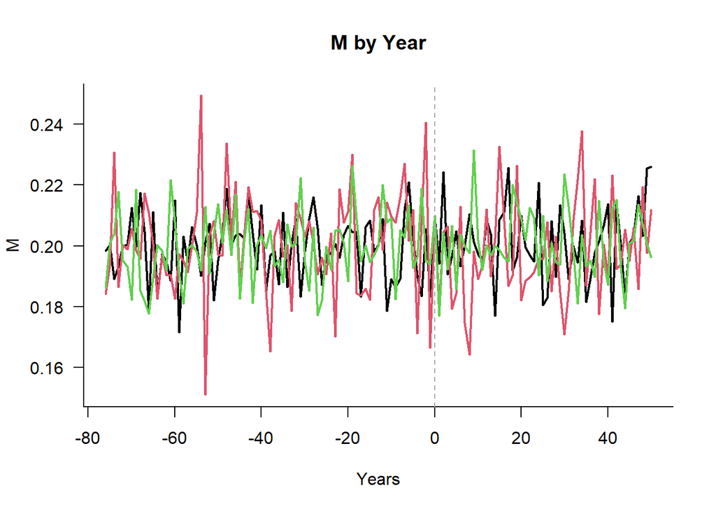

#### M-at-Age

Natural mortality-at-age for 3 simulations in the first historical year, the last historical year (i.e., current year), and the last projected year:

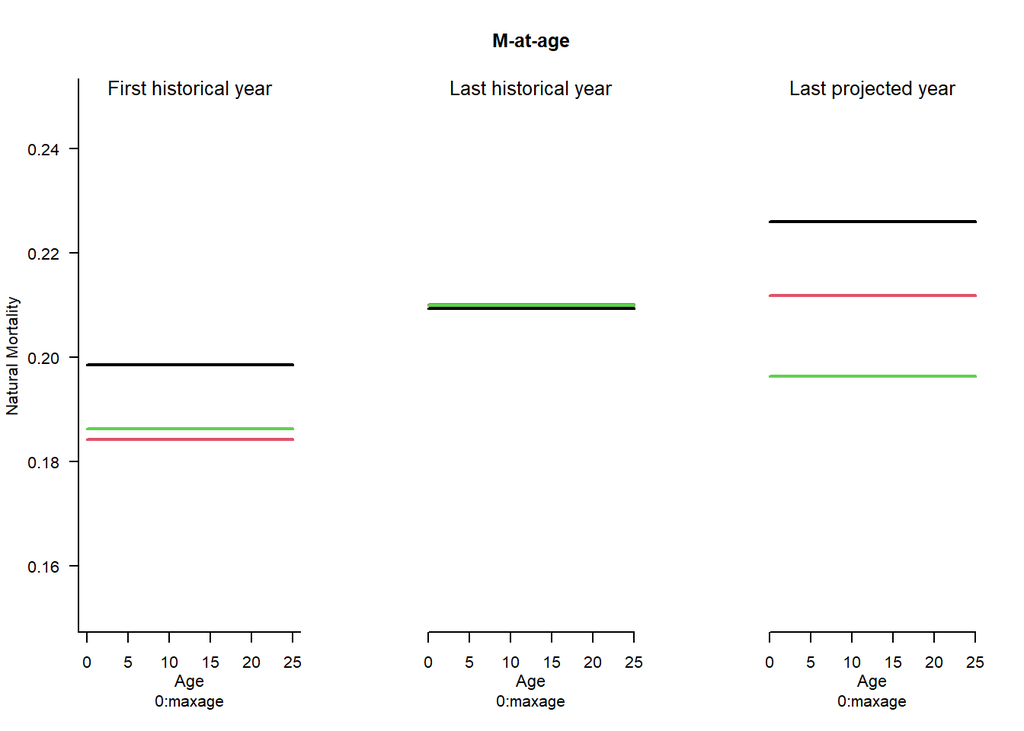

#### M-at-Length

Natural mortality-at-length for 3 simulations in the first historical year, the last historical year (i.e., current year), and the last projected year:

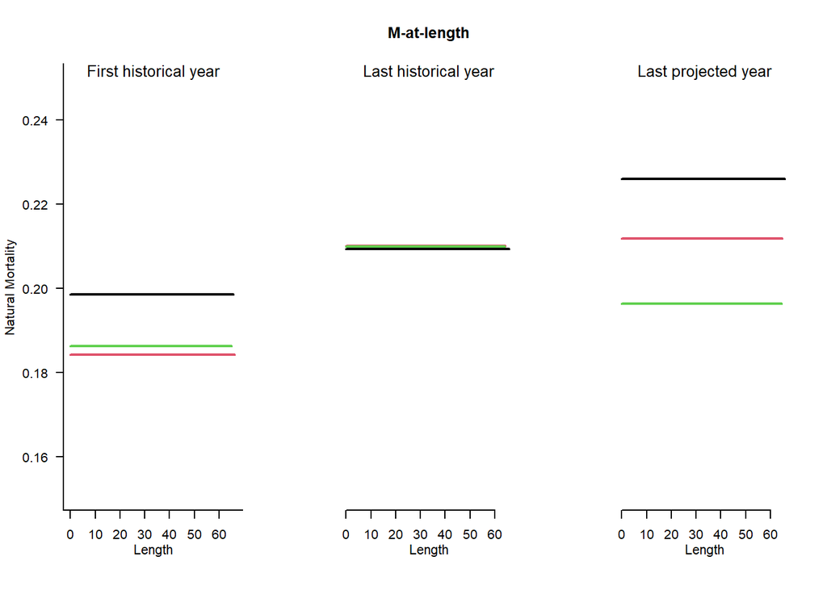

### Recruitment: h, SRrel, Perr, AC

**h**: Steepness of the stock recruit relationship. Uniform distribution lower and upper bounds. Values from 1/5 to 1

Specified Value(s): 0.64, 0.82

Bounds for steepness were based on the 20th and 80th percentiles estimated by Myers et al (1999) for haddock.

**SRrel**: Type of stock-recruit relationship. Single value, switch (1) Beverton-Holt (2) Ricker. Integer

Specified Value(s): 1

We assumed a Beverton-Holt stock-recruitment relationship.

**Perr**: Process error, the CV of log-normal recruitment deviations. Uniform distribution lower and upper bounds. Non-negative real numbers

Specified Value(s): 0.6, 0.9

No estimates for recruitment variability exist, but recruitment is highly variable for this stock.  
Bounds for this parameter were set to reflect highly variable recruitment.

**AC**: Auto-correlation in recruitment deviations rec(t)=AC*rec(t-1)+(1-AC)*sigma(t). Uniform distribution lower and upper bounds. Non-negative real numbers

Specified Value(s): 0.1, 0.6

A wide range of values was used for auto-correlation in recruitment to reflect the uncertainty in this parameter.

### Recruitment Parameters

#### Sampled Parameters

Histograms of 48 simulations of steepness (`h`), recruitment process error (`Perr`) and auto-correlation (`AC`) for the Beverton-Holt stock-recruitment relationship, with vertical colored lines indicating 3 randomly drawn values used in other plots:

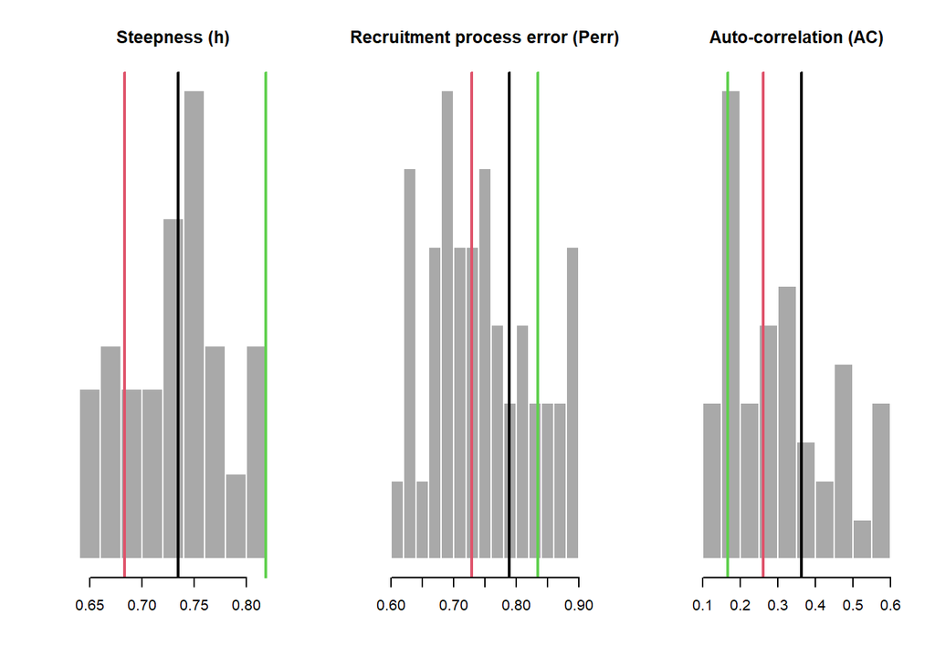

#### Time-Series

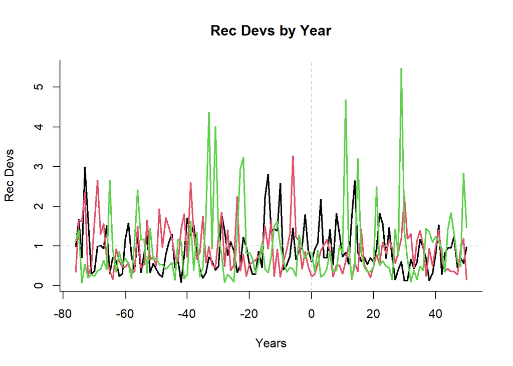

### Growth: Linf, K, t0, LenCV, Ksd, Linfsd

**Linf**: Maximum length. Uniform distribution lower and upper bounds. Positive real numbers

Specified Value(s): 59.85, 66.15

Magnussen (2007) reported *Linf* of 63 cm. We assumed an arbitrary 5% CV to account for some uncertainty in *Linf*.

**K**: von Bertalanffy growth parameter k. Uniform distribution lower and upper bounds. Positive real numbers

Specified Value(s): 0.43, 0.47

Magnussen (2007) reported *K* of 0.452 cm. We assumed an arbitrary 5% CV to account for some uncertainty in *K*

**t0**: von Bertalanffy theoretical age at length zero. Uniform distribution lower and upper bounds. Non-positive real numbers

Specified Value(s): 0, 0

Magnussen (2007) did not report estimates of *t0*. It was assumed that fish at age 0 are length 0.

**LenCV**: Coefficient of variation of length-at-age (assumed constant for all age classes). Uniform distribution lower and upper bounds. Positive real numbers

Specified Value(s): 0.1, 0.15

Default values were used for the variability in length-at-age.

**Ksd**: Inter-annual variability in growth parameter k expressed as coefficient of variation. Uniform distribution lower and upper bounds. Non-negative real numbers

Specified Value(s): 0, 0.03

A small amount of inter-annual variability in *K* was assumed.

**Linfsd**: Inter-annual variability in maximum length expressed as a coefficient of variation. Uniform distribution lower and upper bounds. Non-negative real numbers

Specified Value(s): 0, 0.03

A small amount of inter-annual variability in *Linf* was assumed.

### Growth Parameters

#### Sampled Parameters

Histograms of simulations of von Bertalanffy growth parameters `Linf`, `K`, and `t0`, and inter-annual variability in Linf and K (`Linfsd` and `Ksd`), with vertical colored lines indicating 3 randomly drawn values used in other plots:

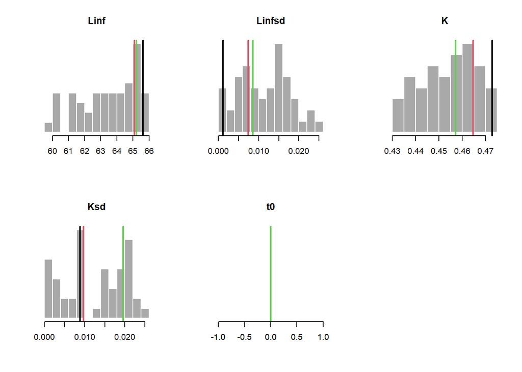

#### Time-Series

The Linf and K parameters in each year for 3 simulations. The vertical dashed line indicates the end of the historical period:

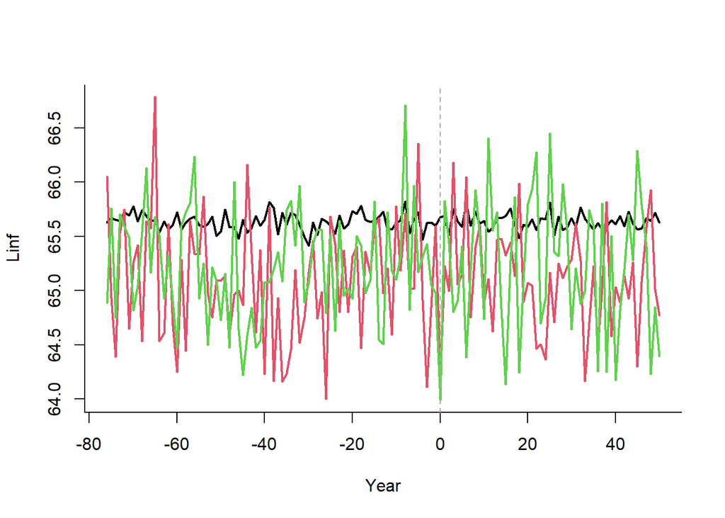

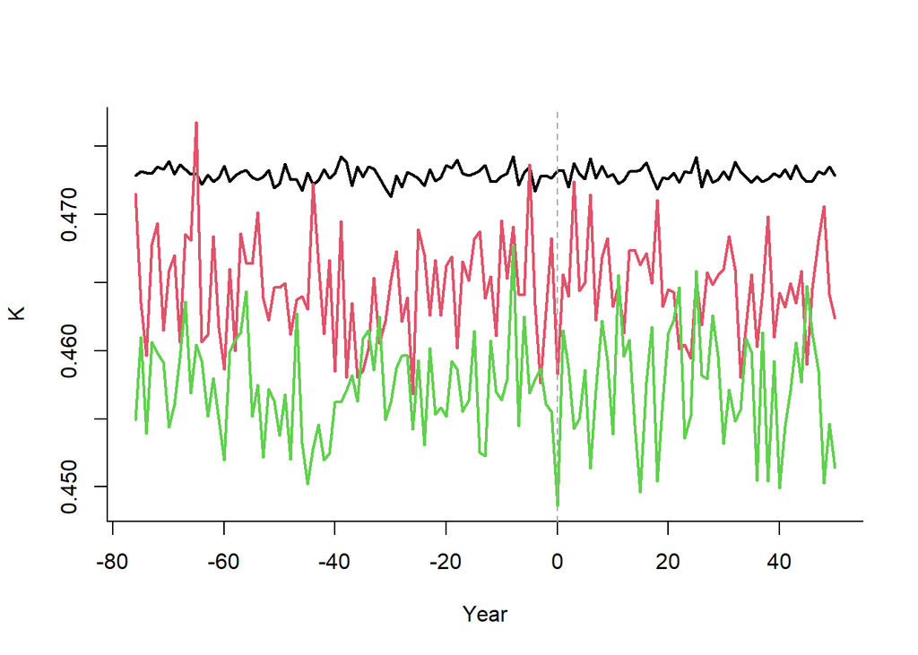

#### Growth Curves

Sampled length-at-age curves for 3 simulations in the first historical year, the last historical year, and the last projection year.

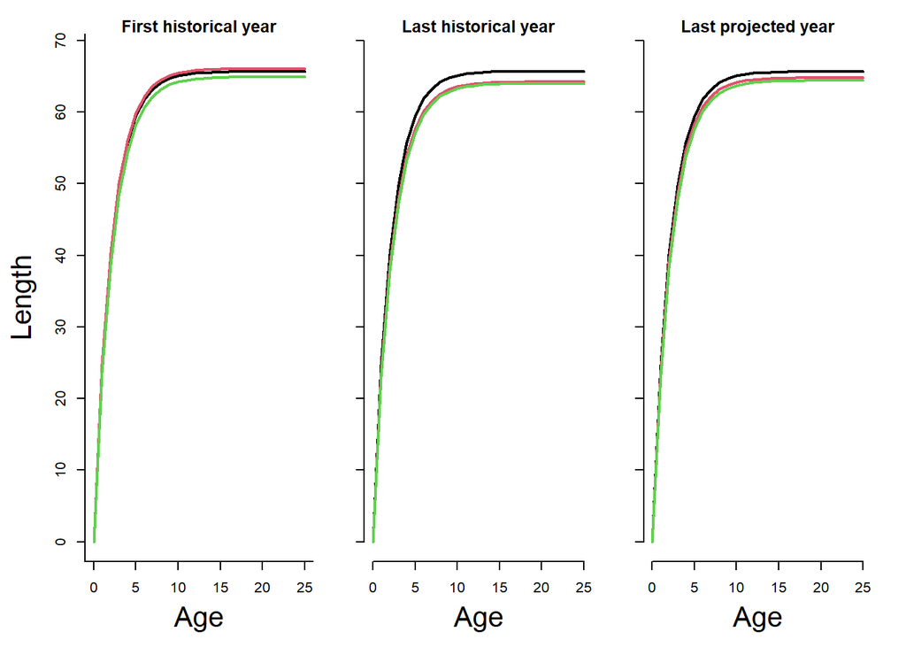

### Maturity: L50, L50_95

**L50**: Length at 50 percent maturity. Uniform distribution lower and upper bounds. Positive real numbers

Specified Value(s): 43.7, 48.3

Magnussen (2007) reported at length-of-maturity of 46 cm for haddock. We assumed an arbitrary 5% CV to account for some uncertainty in *L50*.

**L50_95**: Length increment from 50 percent to 95 percent maturity. Uniform distribution lower and upper bounds. Positive real numbers

Specified Value(s): 4, 5

The difference between length at 50% and 95% maturity was assumed to be small (about 10% of *L50*).

### Maturity Parameters

#### Sampled Parameters

Histograms of simulations of `L50` (length at 50% maturity), `L95` (length at 95% maturity), and corresponding derived age at maturity parameters (`A50` and `A95`), with vertical colored lines indicating 3 randomly drawn values used in other plots:

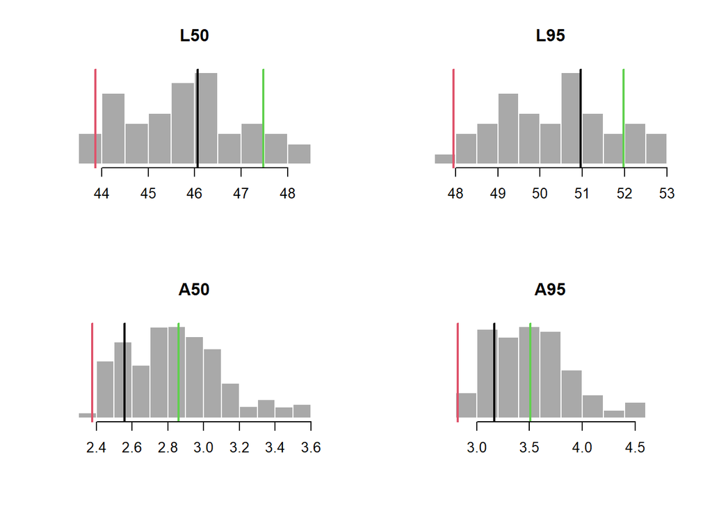

#### Maturity at Age and Length

Maturity-at-age and -length for 3 simulations in the first historical year, the last historical year (i.e., current year), and the last projected year:

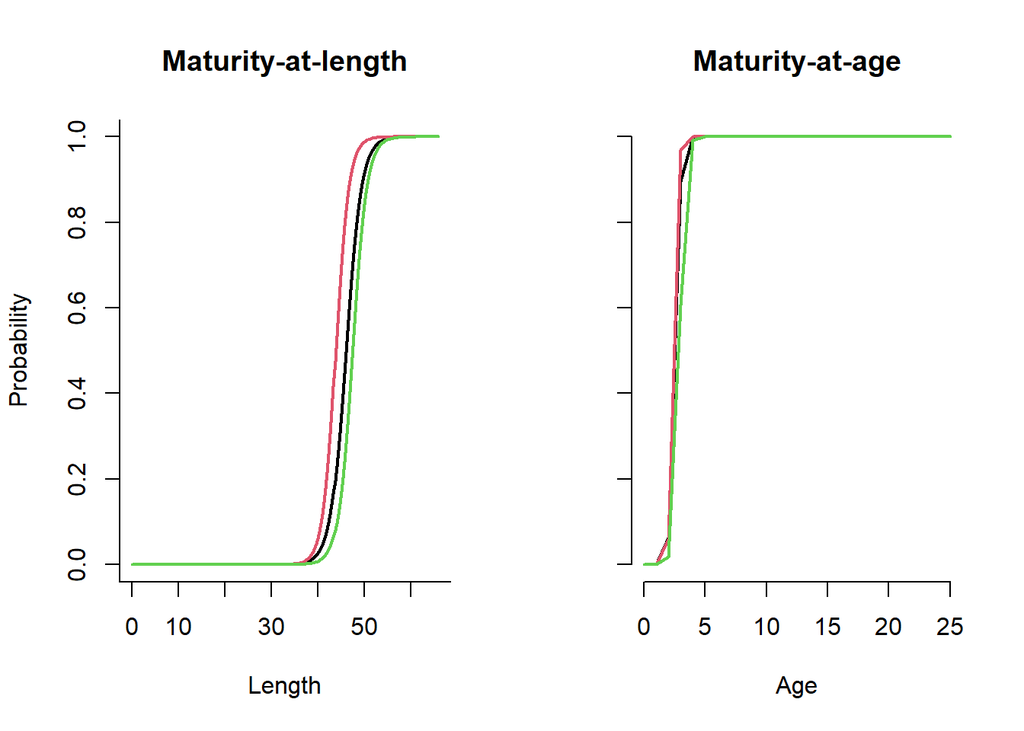

### Stock depletion and Discard Mortality: D, Fdisc

**D**: Current level of stock depletion SSB(current)/SSB(unfished). Uniform distribution lower and upper bounds. Fraction

Specified Value(s): 0.48, 0.66

ICES 2013 reported an estimate of BMSY of 35,000 tonnes. We assumed that BMSY/B0 is ~0.4 based on the steepness values used for this stock, and calculated an unfished spawning biomass of 87,500 tonnes. ICES 2013 report spawning biomass in 1996 of 50,682 tonnes. Based on these values, we calculate depletion in 1996 as 0.57 and assumed a CV of 15% to account for uncertainty.

**Fdisc**: Fraction of discarded fish that die. Uniform distribution lower and upper bounds. Non-negative real numbers

Specified Value(s): 0, 0

The base-case model assumed no discarding and no discard mortality.

### Depletion and Discard Mortality

#### Sampled Parameters

Histograms of simulations of depletion (spawning biomass in the last historical year over average unfished spawning biomass; `D`) and the fraction of discarded fish that are killed by fishing mortality (`Fdisc`), with vertical colored lines indicating 3 randomly drawn values.

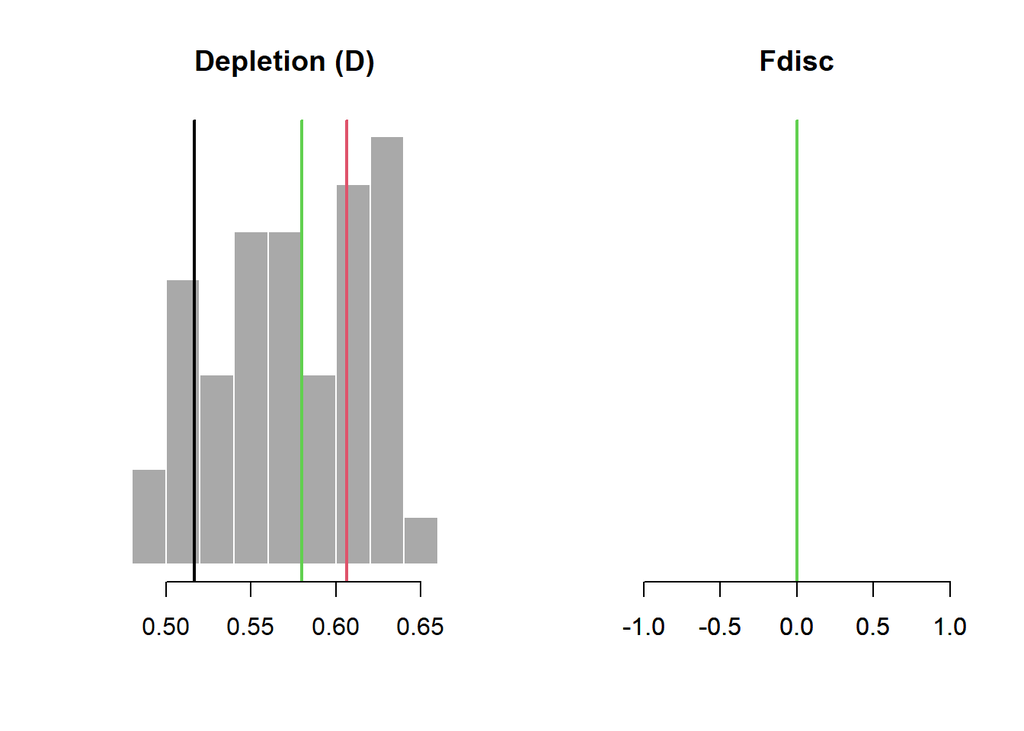

### Length-weight conversion parameters: a, b

**a**: Length-weight parameter alpha. Single value. Positive real number

Specified Value(s): 0.01

Length-weight parameters were based on average values reported in FishBase.

**b**: Length-weight parameter beta. Single value. Positive real number

Specified Value(s): 3.13

Length-weight parameters were based on average values reported in FishBase.

### Spatial distribution and movement: Size_area_1, Frac_area_1, Prob_staying

**Size_area_1**: The size of area 1 relative to area 2. Uniform distribution lower and upper bounds. Positive real numbers

Specified Value(s): 0.5, 0.5

A mixed stock is assumed

**Frac_area_1**: The fraction of the unfished biomass in stock 1. Uniform distribution lower and upper bounds. Positive real numbers

Specified Value(s): 0.5, 0.5

A mixed stock is assumed.

**Prob_staying**: The probability of individuals in area 1 remaining in area 1 over the course of one year. Uniform distribution lower and upper bounds. Positive fraction.

Specified Value(s): 0.5, 0.5

A mixed stock is assumed

### Spatial & Movement

#### Sampled Parameters

Histograms of 48 simulations of size of area 1 (`Size_area_1`), fraction of unfished biomass in area 1 (`Frac_area_1`), and the probability of staying in area 1 in a year (`Frac_area_1`), with vertical colored lines indicating 3 randomly drawn values used in other plots:

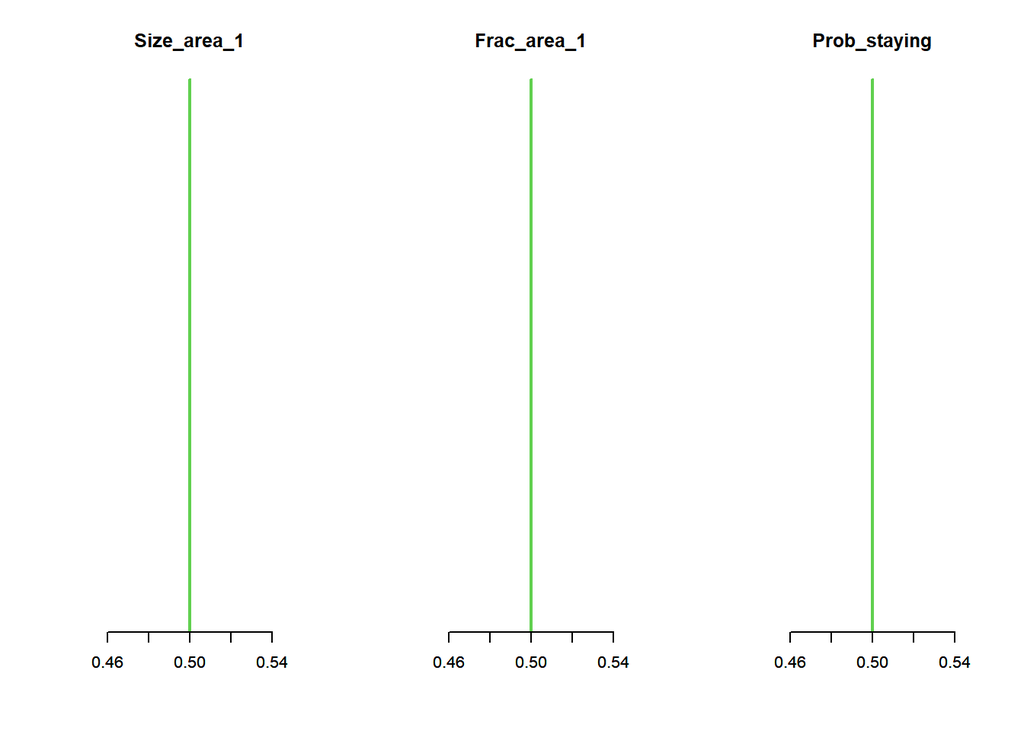

# Fleet Parameters

### Historical years of fishing, spatial targeting: nyears, Spat_targ

**nyears**: The number of years for the historical spool-up simulation. Single value. Positive integer

Specified Value(s): 77

**Spat_targ**: Distribution of fishing in relation to spatial biomass: fishing distribution is proportional to B^Spat_targ. Uniform distribution lower and upper bounds. Real numbers

Specified Value(s): 1, 1

We use the default assumption that effort distributed in proportion to density.

### Trend in historical fishing effort (exploitation rate), interannual variability in fishing effort: EffYears, EffLower, EffUpper, Esd

**EffYears**: Years representing join-points (vertices) of time-varying effort. Vector. Non-negative real numbers

See nyears above.

**EffLower**: Lower bound on relative effort corresponding to EffYears. Vector. Non-negative real numbers

**EffUpper**: Upper bound on relative effort corresponding to EffYears. Vector. Non-negative real numbers

See EffLower.

| EffYears | EffLower | EffUpper |
| --- | --- | --- |
| 1920 | 0.0000 | 0.0000 |
| 1921 | 0.0119 | 0.0146 |
| 1922 | 0.0238 | 0.0291 |
| 1923 | 0.0358 | 0.0437 |
| 1924 | 0.0477 | 0.0583 |
| 1925 | 0.0596 | 0.0728 |
| 1926 | 0.0715 | 0.0874 |
| 1927 | 0.0834 | 0.1020 |
| 1928 | 0.0954 | 0.1170 |
| 1929 | 0.1070 | 0.1310 |
| 1930 | 0.1190 | 0.1460 |
| 1931 | 0.1310 | 0.1600 |
| 1932 | 0.1430 | 0.1750 |
| 1933 | 0.1550 | 0.1890 |
| 1934 | 0.1670 | 0.2040 |
| 1935 | 0.1790 | 0.2190 |
| 1936 | 0.1910 | 0.2330 |
| 1937 | 0.2030 | 0.2480 |
| 1938 | 0.2150 | 0.2620 |
| 1939 | 0.2260 | 0.2770 |
| 1940 | 0.2380 | 0.2910 |
| 1941 | 0.2500 | 0.3060 |
| 1942 | 0.2620 | 0.3200 |
| 1943 | 0.2740 | 0.3350 |
| 1944 | 0.2860 | 0.3500 |
| 1945 | 0.2980 | 0.3640 |
| 1946 | 0.3100 | 0.3790 |
| 1947 | 0.3220 | 0.3930 |
| 1948 | 0.3340 | 0.4080 |
| 1949 | 0.3460 | 0.4220 |
| 1950 | 0.3580 | 0.4370 |
| 1951 | 0.3690 | 0.4520 |
| 1952 | 0.3810 | 0.4660 |
| 1953 | 0.3930 | 0.4810 |
| 1954 | 0.4050 | 0.4950 |
| 1955 | 0.4170 | 0.5100 |
| 1956 | 0.4290 | 0.5240 |
| 1957 | 0.4410 | 0.5390 |
| 1958 | 0.5640 | 0.6900 |
| 1959 | 0.5130 | 0.6270 |
| 1960 | 0.6390 | 0.7810 |
| 1961 | 0.5060 | 0.6190 |
| 1962 | 0.5860 | 0.7160 |
| 1963 | 0.6300 | 0.7700 |
| 1964 | 0.4280 | 0.5230 |
| 1965 | 0.4730 | 0.5790 |
| 1966 | 0.4760 | 0.5820 |
| 1967 | 0.3630 | 0.4430 |
| 1968 | 0.3940 | 0.4810 |
| 1969 | 0.4370 | 0.5340 |
| 1970 | 0.4290 | 0.5240 |
| 1971 | 0.4110 | 0.5020 |
| 1972 | 0.3570 | 0.4360 |
| 1973 | 0.2610 | 0.3190 |
| 1974 | 0.1990 | 0.2430 |
| 1975 | 0.1620 | 0.1980 |
| 1976 | 0.2230 | 0.2720 |
| 1977 | 0.3490 | 0.4260 |
| 1978 | 0.2500 | 0.3060 |
| 1979 | 0.1400 | 0.1710 |
| 1980 | 0.1600 | 0.1960 |
| 1981 | 0.1630 | 0.2000 |
| 1982 | 0.2980 | 0.3640 |
| 1983 | 0.2390 | 0.2920 |
| 1984 | 0.2060 | 0.2510 |
| 1985 | 0.2480 | 0.3040 |
| 1986 | 0.2010 | 0.2460 |
| 1987 | 0.2380 | 0.2910 |
| 1988 | 0.1810 | 0.2210 |
| 1989 | 0.2570 | 0.3140 |
| 1990 | 0.2460 | 0.3000 |
| 1991 | 0.2480 | 0.3020 |
| 1992 | 0.1900 | 0.2320 |
| 1993 | 0.1690 | 0.2060 |
| 1994 | 0.1860 | 0.2270 |
| 1995 | 0.2040 | 0.2490 |
| 1996 | 0.2880 | 0.3510 |

**Esd**: Additional inter-annual variability in fishing mortality rate. Uniform distribution lower and upper bounds. Non-negative real numbers

Specified Value(s): 0.1, 0.3

Default values were used to allow for additional varability in the historical effort trend.

### Historical Effort

#### Sampled Parameters

Histograms of 48 simulations of inter-annual variability in historical fishing mortality (`Esd`), with vertical colored lines indicating 3 randomly drawn values used in the time-series plot:

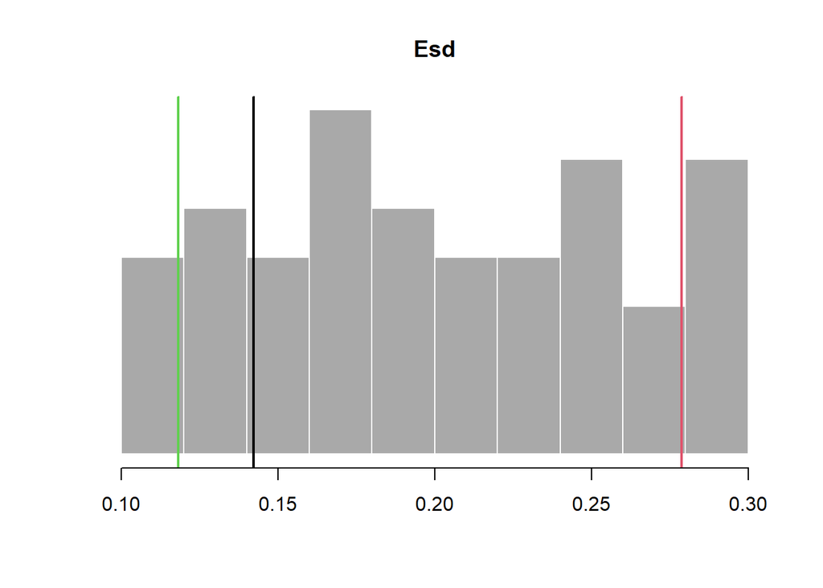

#### Time-Series

Time-series plot showing 3 trends in historical fishing mortality (`OM@EffUpper` and `OM@EffLower` or `OM@cpars$Find`):

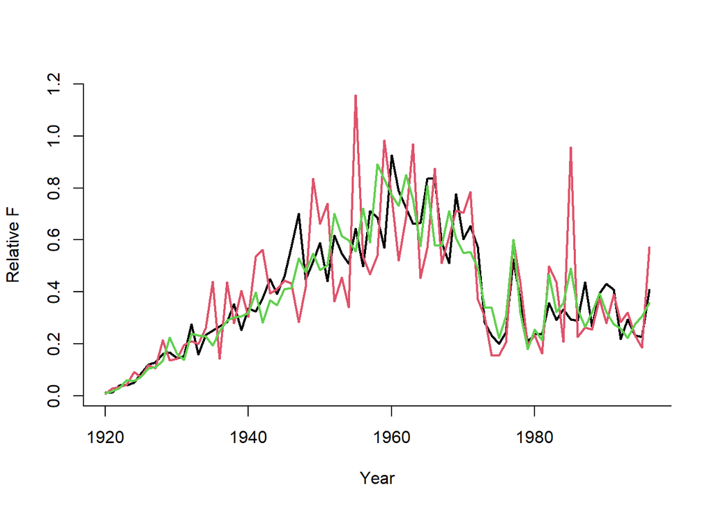

### Annual increase in catchability, interannual variability in catchability: qinc, qcv

**qinc**: Average percentage change in fishing efficiency (applicable only to forward projection and input controls). Uniform distribution lower and upper bounds. Non-negative real numbers

Specified Value(s): 0, 0

The base-case model assumed that catchability was stable and did not change in the future. The alternative OMs examine the increase in catchability that was observed in this fishery from 1996 onwards.

**qcv**: Inter-annual variability in fishing efficiency (applicable only to forward projection and input controls). Uniform distribution lower and upper bounds. Non-negative real numbers

Specified Value(s): 0.05, 0.1

We assume some variability in fishing efficiency among years.

### Future Catchability

#### Sampled Parameters

Histograms of 48 simulations of inter-annual variability in fishing efficiency (`qcv`) and average annual change in fishing efficiency (`qinc`), with vertical colored lines indicating 3 randomly drawn values used in the time-series plot:

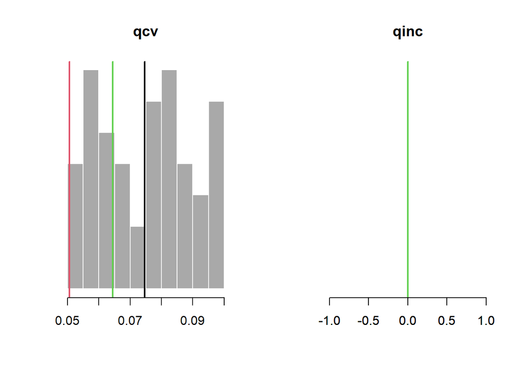

#### Time-Series

Time-series plot showing 3 trends in future fishing efficiency (catchability):

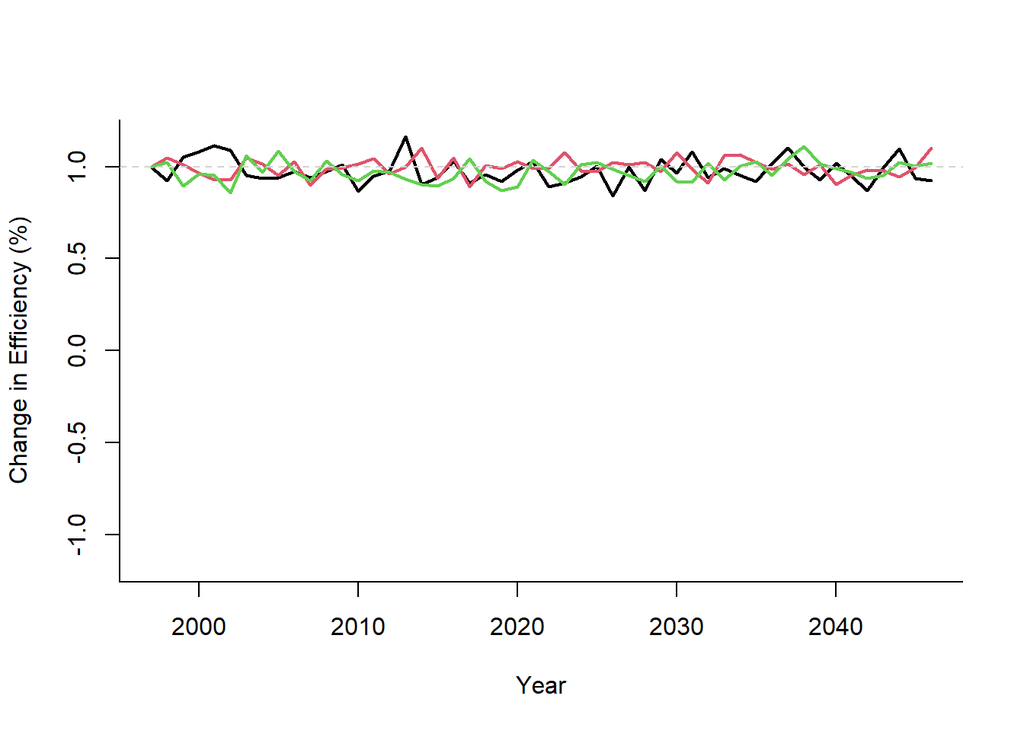

### Fishery gear length selectivity: L5, LFS, Vmaxlen, isRel

**L5**: Shortest length corresponding to 5 percent vulnerability. Uniform distribution lower and upper bounds. Positive real numbers

Specified Value(s): 28, 33

Selectivity-at-length was based on the catch-at-age data reported in the 2008 ICES assessment and the von Bertalanffy  
growth parameters reported above.

**LFS**: Shortest length that is fully vulnerable to fishing. Uniform distribution lower and upper bounds. Positive real numbers

Specified Value(s): 47, 54

See L5.

**Vmaxlen**: The vulnerability of fish at Stock@Linf . Uniform distribution lower and upper bounds. Fraction

Specified Value(s): 1, 1

Selectivity was assumed to be asymptotic.

**isRel**: Selectivity parameters in units of size-of-maturity (or absolute eg cm). Single value. Boolean

Specified Value(s): FALSE

The selectivity parameters are set as absolute sizes (not relative to the size of maturity)..

### Fishery length retention: LR5, LFR, Rmaxlen, DR

**LR5**: Shortest length corresponding ot 5 percent retention. Uniform distribution lower and upper bounds. Non-negative real numbers

Specified Value(s): 0, 0

We assume that all fish in the catch are retained.

**LFR**: Shortest length that is fully retained. Uniform distribution lower and upper bounds. Non-negative real numbers

Specified Value(s): 0, 0

We assume that all fish in the catch are retained.

**Rmaxlen**: The retention of fish at Stock@Linf . Uniform distribution lower and upper bounds. Non-negative real numbers

Specified Value(s): 1, 1

We assume that all fish in the catch are retained.

**DR**: Discard rate - the fraction of caught fish that are discarded. Uniform distribution lower and upper bounds. Fraction

Specified Value(s): 0, 0

We assume that all fish in the catch are retained.

### Current Year: CurrentYr

**CurrentYr**: The current calendar year (final year) of the historical simulations (eg 2011). Single value. Positive integer

Specified Value(s): 1996

The OM was based on the fishery in 1996.

### Existing Spatial Closures: MPA

**MPA**: Is Area 1 currently closed (TRUE) or open (FALSE)? Defaults to FALSE

Specified Value(s): FALSE

No MPA was included in the OM.

# Obs Parameters

The observation model parameters are taken from the Generic_Obs model in DLMtool.

### Catch statistics: Cobs, Cbiascv, CAA_nsamp, CAA_ESS, CAL_nsamp, CAL_ESS

**Cobs**: Log-normal catch observation error expressed as a coefficient of variation. Uniform distribution lower and upper bounds. Non-negative real numbers

Specified Value(s): 0.1, 0.3

Borrowed from: Generic_Obs

**Cbiascv**: Log-normal coefficient of variation controlling the sampling of bias in catch observations for each simulation. Single value. Non-negative real number

Specified Value(s): 0.1

Borrowed from: Generic_Obs

**CAA_nsamp**: Number of catch-at-age observation per time step. Uniform distribution lower and upper bounds. Positive real numbers

Specified Value(s): 100, 200

Borrowed from: Generic_Obs

**CAA_ESS**: Effective sample size (independent age draws) of the multinomial catch-at-age observation error model. Uniform distribution lower and upper bounds. Positive integers

Specified Value(s): 25, 50

Borrowed from: Generic_Obs

**CAL_nsamp**: Number of catch-at-length observation per time step. Uniform distribution lower and upper bounds. Positive integers

Specified Value(s): 100, 200

Borrowed from: Generic_Obs

**CAL_ESS**: Effective sample size (independent length draws) of the multinomial catch-at-length observation error model. Uniform distribution lower and upper bounds. Positive integers

Specified Value(s): 25, 50

Borrowed from: Generic_Obs

### Index imprecision, bias and hyperstability: Iobs, Btobs, Btbiascv, beta

**Iobs**: Observation error in the relative abundance indices expressed as a coefficient of variation. Uniform distribution lower and upper bounds. Positive real numbers

Specified Value(s): 0.1, 0.4

Borrowed from: Generic_Obs

**Btobs**: Log-normal coefficient of variation controlling error in observations of current stock biomass among years. Uniform distribution lower and upper bounds. Positive real numbers

Specified Value(s): 0.2, 0.5

Borrowed from: Generic_Obs

**Btbiascv**: Uniform-log bounds for sampling persistent bias in current stock biomass. Uniform-log distribution lower and upper bounds. Positive real numbers

Specified Value(s): 0.33, 3

Borrowed from: Generic_Obs

**beta**: A parameter controlling hyperstability/hyperdepletion where values below 1 lead to hyperstability (an index that decreases slower than true abundance) and values above 1 lead to hyperdepletion (an index that decreases more rapidly than true abundance). Uniform distribution lower and upper bounds. Positive real numbers

Specified Value(s): 0.5, 2

Borrowed from: Generic_Obs

### Bias in maturity, natural mortality rate and growth parameters: LenMbiascv, Mbiascv, Kbiascv,t0biascv, Linfbiascv

**LenMbiascv**: Log-normal coefficient of variation for sampling persistent bias in length at 50 percent maturity. Single value. Positive real numbers

Specified Value(s): 0.1

Borrowed from: Generic_Obs

**Mbiascv**: Log-normal coefficient of variation for sampling persistent bias in observed natural mortality rate. Single value. Positive real number

Specified Value(s): 0.2

Borrowed from: Generic_Obs

**Kbiascv**: Log-normal coefficient of variation for sampling persistent bias in observed growth parameter K. Single value. Positive real number

Specified Value(s): 0.1

Borrowed from: Generic_Obs

**t0biascv**: Log-normal coefficient of variation for sampling persistent bias in observed t0. Single value. Positive real number

Specified Value(s): 0.1

Borrowed from: Generic_Obs

**Linfbiascv**: Log-normal coefficient of variation for sampling persistent bias in observed maximum length. Single value. Positive real number

Specified Value(s): 0.05

Borrowed from: Generic_Obs

### Bias in length at first capture, length at full selection: LFCbiascv, LFSbiascv

**LFCbiascv**: Log-normal coefficient of variation for sampling persistent bias in observed length at first capture. Single value. Positive real number

Specified Value(s): 0.05

Borrowed from: Generic_Obs

**LFSbiascv**: Log-normal coefficient of variation for sampling persistent bias in length-at-full selection. Single value. Positive real number

Specified Value(s): 0.05

Borrowed from: Generic_Obs

### Bias in fishery reference points, unfished biomass, FMSY, FMSY/M ratio, biomass at MSY relative to unfished: FMSY_Mbiascv, BMSY_B0biascv

**FMSY_Mbiascv**: Log-normal coefficient of variation for sampling persistent bias in FMSY/M. Single value. Positive real number

Specified Value(s): 0.2

Borrowed from: Generic_Obs

**BMSY_B0biascv**: Log-normal coefficient of variation for sampling persistent bias in BMSY relative to unfished. Single value. Positive real number

Specified Value(s): 0.2

Borrowed from: Generic_Obs

### Management targets in terms of the index (i.e., model free), the total annual catches and absolute biomass levels: Irefbiascv, Crefbiascv, Brefbiascv

**Irefbiascv**: Log-normal coefficient of variation for sampling persistent bias in relative abundance index at BMSY. Single value. Positive real number

Specified Value(s): 0.2

Borrowed from: Generic_Obs

**Crefbiascv**: Log-normal coefficient of variation for sampling persistent bias in MSY. Single value. Positive real number

Specified Value(s): 0.2

Borrowed from: Generic_Obs

**Brefbiascv**: Log-normal coefficient of variation for sampling persistent bias in BMSY. Single value. Positive real number

Specified Value(s): 0.5

Borrowed from: Generic_Obs

### Depletion bias and imprecision: Dbiascv, Dobs

**Dbiascv**: Log-normal coefficient of variation for sampling persistent bias in stock depletion. Single value. Positive real number

Specified Value(s): 0.5

Borrowed from: Generic_Obs

**Dobs**: Log-normal coefficient of variation controlling error in observations of stock depletion among years. Uniform distribution lower and upper bounds. Positive real numbers

Specified Value(s): 0.05, 0.1

Borrowed from: Generic_Obs

### Recruitment compensation and trend: hbiascv, Recbiascv, sigmaRbiascv

**hbiascv**: Log-normal coefficient of variation for sampling persistent bias in steepness. Single value. Positive real number

Specified Value(s): 0.2

Borrowed from: Generic_Obs

**Recbiascv**: Log-normal coefficient of variation for sampling persistent bias in recent recruitment strength. Uniform distribution lower and upper bounds. Positive real numbers

Borrowed from: Generic_Obs

**sigmaRbiascv**: Log-normal coefficeint of variation for sampling persistent bias in recruitment variability. Single value. Positive real number

Specified Value(s): 0.1

No justification provided.

### Effort: Eobs, Ebiascv

**Eobs**: Log-normal effort observation error expressed as a coefficient of variation. Uniform distribution lower and upper bounds. Non-negative real numbers

Slot not used.

**Ebiascv**: Log-normal coefficient of variation controlling the sampling of bias in effort observations for each simulation. Single value. Non-negative real number

Slot not used.

## Observation Parameters

### Catch Observations

#### Sampled Parameters

Histograms of 48 simulations of inter-annual variability in catch observations (`Csd`) and persistent bias in observed catch (`Cbias`), with vertical colored lines indicating 3 randomly drawn values used in other plots:

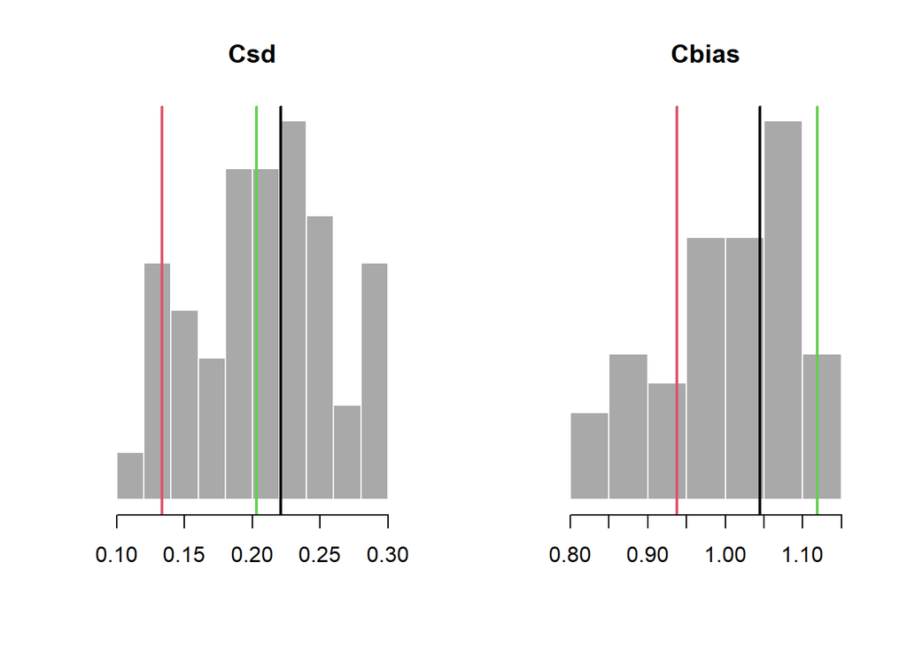

#### Time-Series

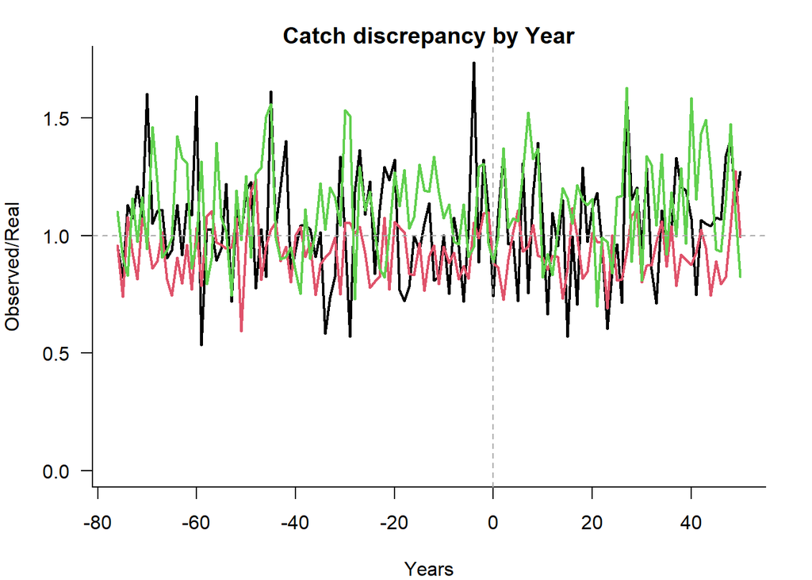

### Depletion Observations

#### Sampled Parameters

Histograms of 48 simulations of inter-annual variability in depletion observations (`Dobs`) and persistent bias in observed depletion (`Dbias`), with vertical colored lines indicating 3 randomly drawn values used in other plots:

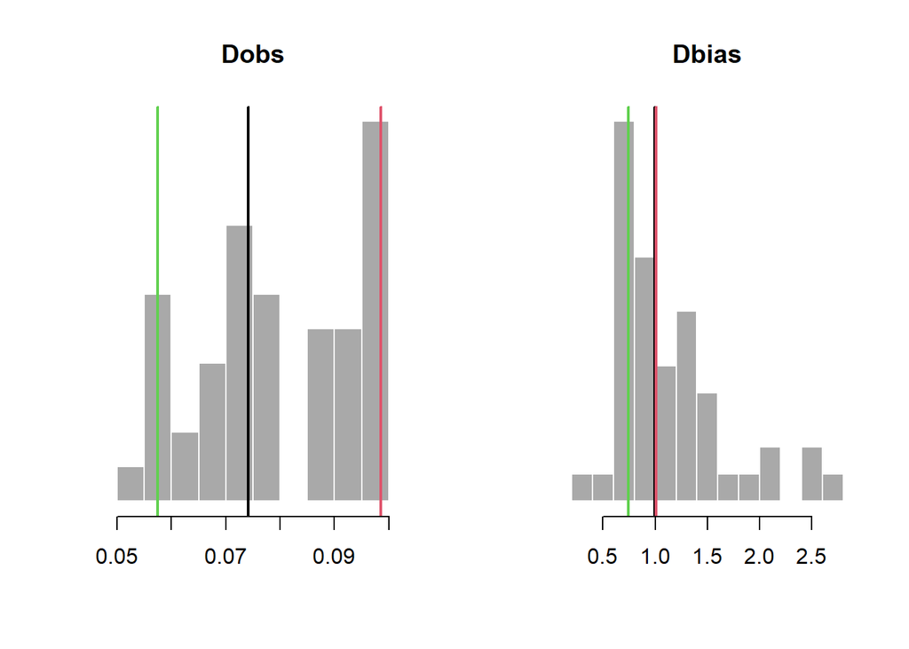

#### Time-Series

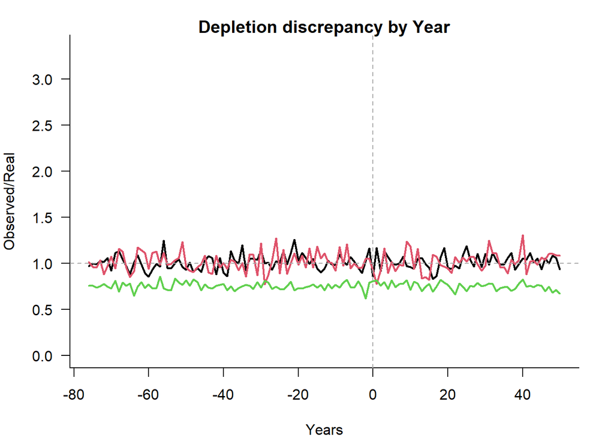

### Abundance Observations

#### Sampled Parameters

Histograms of 48 simulations of inter-annual variability in abundance observations (`Btobs`) and persistent bias in observed abundance (`Btbias`), with vertical colored lines indicating 3 randomly drawn values used in other plots:

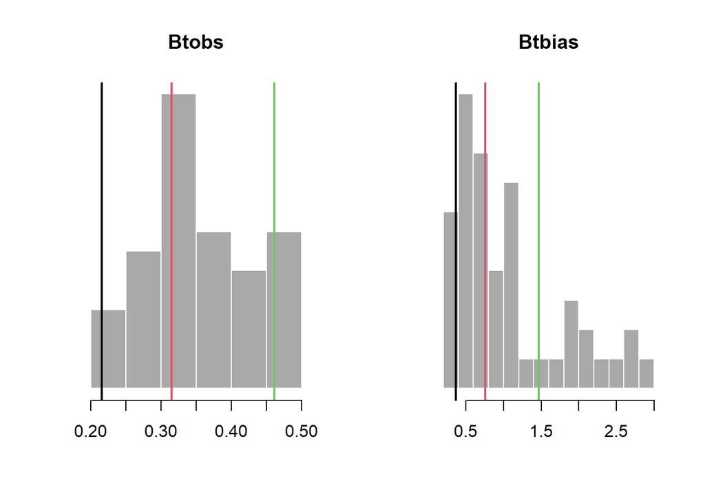

#### Time-Series

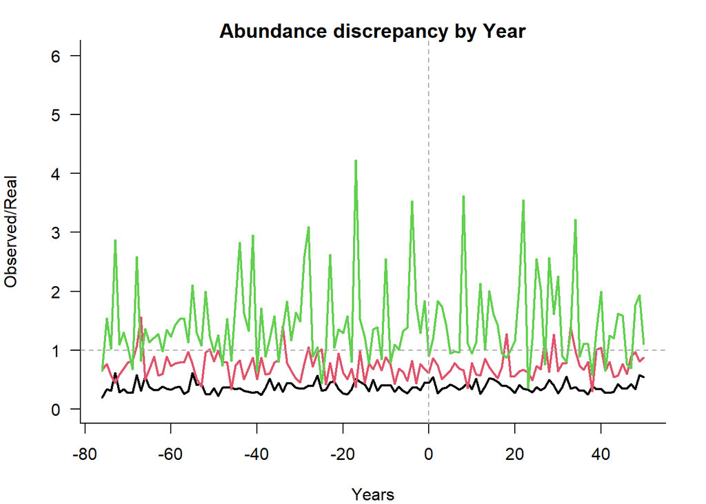

### Index Observations

#### Sampled Parameters

Histograms of 48 simulations of inter-annual variability in index observations (`Iobs`) and hyper-stability/depletion in observed index (`beta`), with vertical colored lines indicating 3 randomly drawn values used in other plots:

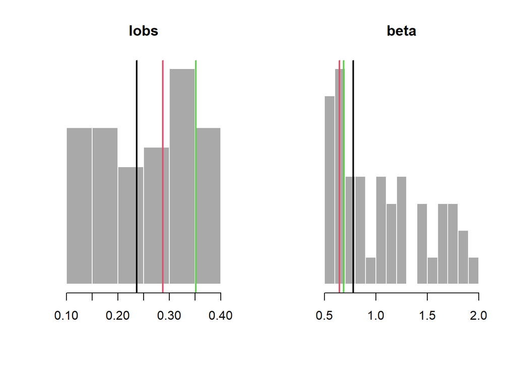

#### Time-Series

Time-series plot of 3 samples of index observation error:

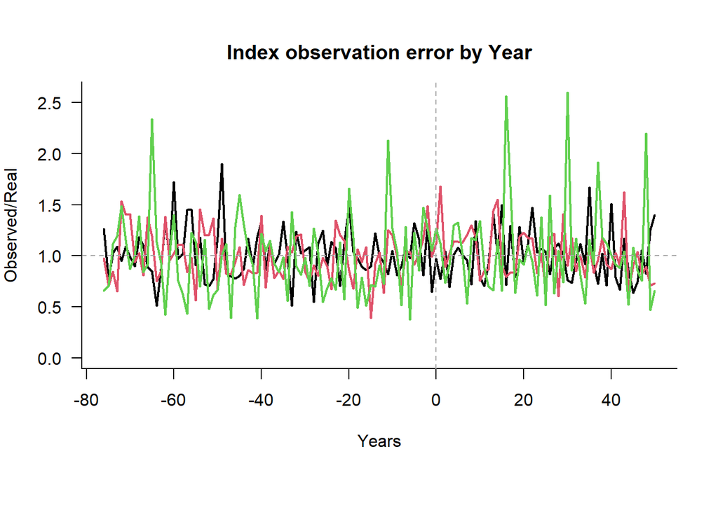

Plot showing an example true abundance index (blue) with 3 samples of index observation error and the hyper-stability/depletion parameter (`beta`):

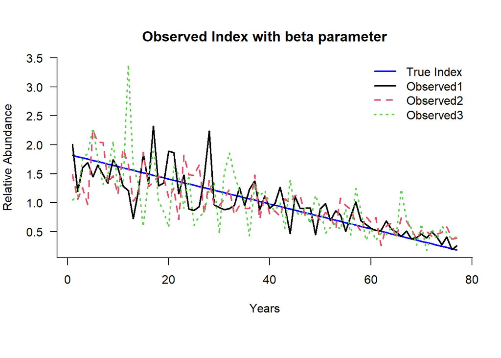

### Recruitment Observations

#### Sampled Parameters

Histograms of 48 simulations of inter-annual variability in index observations (`Recsd`) , with vertical colored lines indicating 3 randomly drawn values used in other plots:

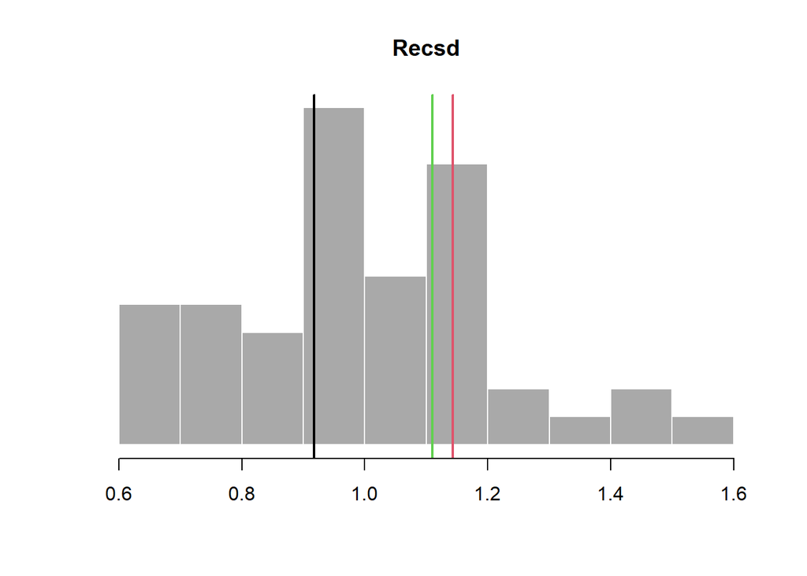

#### Time-Series

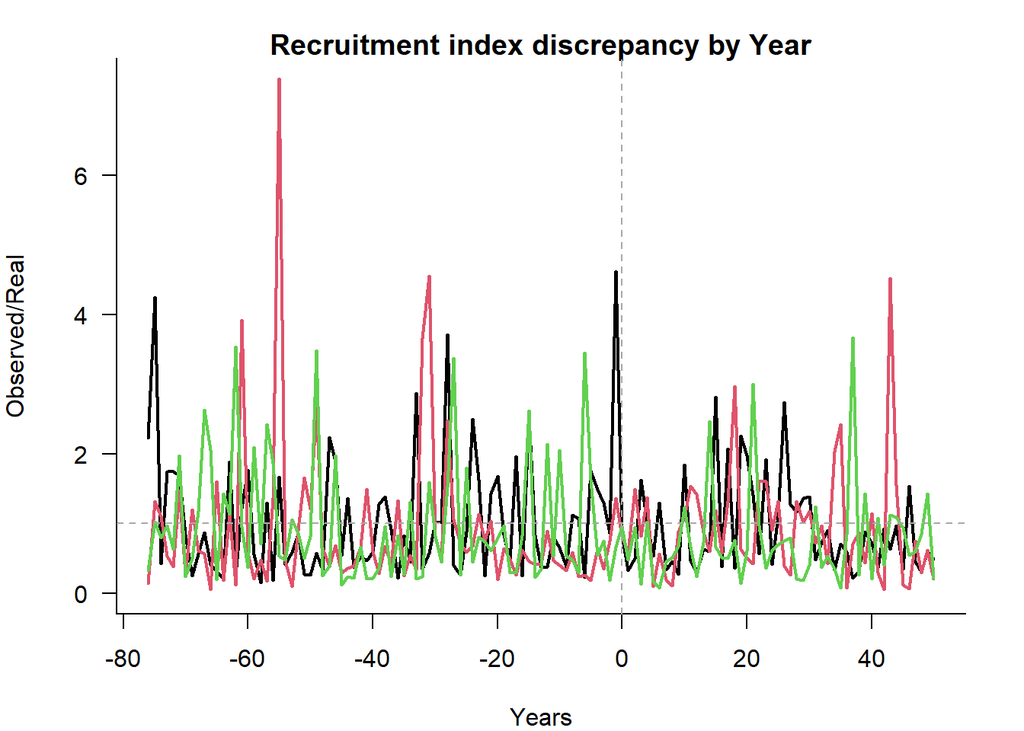

### Composition Observations

#### Sampled Parameters

Histograms of 48 simulations of catch-at-age effective sample size (`CAA_ESS`) and sample size (`CAA_nsamp`) and catch-at-length effective (`CAL_ESS`) and actual sample size (`CAL_nsamp`) with vertical colored lines indicating 3 randomly drawn values:

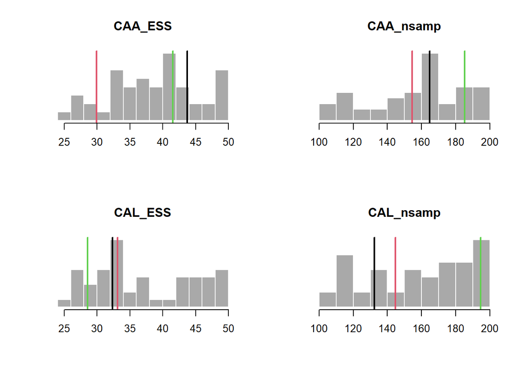

### Parameter Observations

#### Sampled Parameters

Histograms of 48 simulations of bias in observed natural mortality (`Mbias`), von Bertalanffy growth function parameters (`Linfbias`, `Kbias`, and `t0bias`), length-at-maturity (`lenMbias`), and bias in observed length at first capture (`LFCbias`) and first length at full capture (`LFSbias`) with vertical colored lines indicating 3 randomly drawn values:

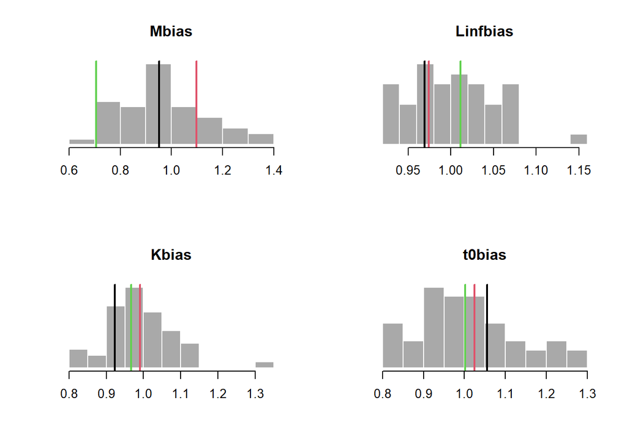

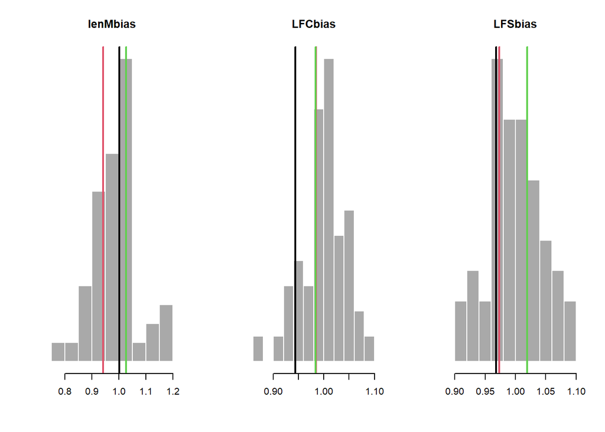